# Tuning Your Classifiers:

## A primitive OCR using `sklearn.ensemble`

There are many different classification algorithms, and the decision for which one to use is based on the problem. It is impossible, however, to always know which one to use A priori, so this often means a multitude of classifiers must be tested before hand. We start by loading the libraries I'll need. Perhaps most importantly, we'll need Python's Mathine learning library `sklearn`, which is short for `scikit-Learn`.

```python
import numpy as np
from numba import jit
from math import sqrt
from sklearn.ensemble import GradientBoostingClassifier,RandomForestClassifier,BaggingClassifier,AdaBoostClassifier
from sklearn.svm import LinearSVC
```

Python's numerical library `numpy` has a very useful feature called `loadtxt`, which easily fills an numpy array with numeric data from a text file. Keep in mind that `loadtxt` can only read numeric data and will throw an error if you try to load a text column or row. Thankfully, there are parameters that can be set to exclude rows or columns. Below, we specify that one row will be skipped. The `skiprows` parameter starts at row zero and excludes the number specified, because headers are usually at the top of the document. The `column` parameter takes an array of the columns to be $\textbf{included}$, but defaults to include all columns. Additionally, every value in the file is loaded as a double precision floating point number. The `r"` prefix on the string ensures that windows directory delimeters do not cause escapes by reading the raw text.

```python
x = np.loadtxt(open(r"file.csv","rb"),delimiter=',',skiprows = 1)
```

Because this project was started with very little knowledge of how to approach this problem, we started by organizing the different numbers into their own individual lists. Though this was useul for plotting, it ended up not being used in any of the classifiers.

```python
zs=np.empty(shape=[1])
ons=np.empty(shape=[1])
ts=np.empty(shape=[1])     #
ths=np.empty(shape=[1])    #
frs=np.empty(shape=[1])    #initialize lists for numbers
fvs=np.empty(shape=[1])    #
sxs=np.empty(shape=[1])    #
svs=np.empty(shape=[1])    #
ets=np.empty(shape=[1])
nns=np.empty(shape=[1])
y=x[:,0]

numlists=[zs,ons,ts,ths,frs,fvs,sxs,svs,ets,nns]#list lists

for i in range(y.shape[0]):
    num=y[i].astype(int)                    #sort MNIST images into their lists
    numlists[num]=np.append(numlists[num],i)

for i in range(10):
    numlists[i]=x[numlists[i][1:len(numlists[i])].astype(int),1:x.shape[1]]#extra formatting
    print(numlists[i].shape)
```

```
(4132, 784)
(4684, 784)
(4177, 784)
(4351, 784)
(4072, 784)
(3795, 784)
(4137, 784)
(4401, 784)
(4063, 784)
(4188, 784)
```

Here, we generated some pixel intensity histograms which we also did not end up using. This meant looking at every pixel in every image. Because this is a a big dataset, Just in Time compilation helped generate the histograms in less time in less time.

```python
@jit()#auto-jit decorater (now function below will be compiled)

def freqs(numlist):

    ps=np.empty(shape=[15,784])

    for i in range(numlist.shape[0]):
        for j in range(784):
            for n in range(15):
                if(numlist[i,j]>n*255/15 and numlist[i,j]<(n+1)*255/15): ps[n,j]+=1  #sorts pixels for each num into bins

    return ps.astype(int)
individual_freq_charts=[freqs(numlists[i]) for i in range(10)] #makes list of individual histograms
```

Anyway, to plot the image in Python is also quite simple, using `imshow` from the library `matplotlib.pyplot`. Start by loading a single character from the numlist, the way it was built, the row argument of numlists corresponds with the digit that is displayed. Because `imshow` uses standard greyscale, divide the pixel values by the max pixel value of $255$:

```
(784,)
```

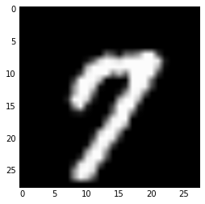

```python
%matplotlib inline         #display plots in window
import matplotlib.pyplot as plt #import plot library

char=numlists[7][100]  #101st element of 7s array
print(char.shape)
char=np.reshape(char,(28,28)) #1x784 array reshape into 28x28 grid

plt.imshow(char/255,cmap='gray') #display
```

Okay, now that that's done, we can get to the $\textbf{SCIENCE}$.

Often when presented with a machine learning problem you, as a researcher, will be given a limited amount of training data, which you will know the attributes and classification of and asked to classify all new data based only on attributes. The problem with this is that the data your machine has to build its model or $\textit{train}$ with may or may not be a strongly representitive sample of real world data. The result of this is an issue called $\textit{overfitting}$. The idea of overfitting is that it is possible to rely too strongly on sample data when building your model and fit your model specifically to the ramdom sample you are given while actually losing accuracy on classification of new data. In practice, the solution to this is the use of a $\textit{holdout group}$. While tuning your classifier, You should exclude your holdout group and then predict the classification of it. Then you can compare the prediction of your model to the actual classifications of your holdout data. This allows you to test your model's error on data that was not included in the training set, an opprotunity you probably won't have with real world data. The tuning process here is a rather simple method of analyzing which attributes are the most statistically relevant, and which classifier parameters are optimal. There are less naive versions of this process known as $\textit{factor analysis}$ Below is an example of how to create a holdout group:

```python
sample=x[np.random.choice(range(10000),size=10000,replace=False),:]#permute images, could also use np.permutation
x_train=sample[range(4000),:] #separate training group
x_train=x_train[:,range(1,784,1)] #separate attributes from training set
y_train=sample[range(4000),0]  #separate classifications for training set
x_test=sample[range(4001,10000,1),:]  #separate holdout group
x_test=x_test[:,range(1,784,1)]  #separate hodout group attributes
y_test=sample[range(4001,10000,1),0]  #separate holdout group classifications
```

```python
sample=np.random.choice(range(80046),size=80046,replace=False)#permute
xvars=list(range(784))
for n in xvars:
    x_train=x[sample[list(range(40001))],:] #train attributes
    x_train1=x_train[:,np.ma.masked_array(xvars, xvars == n)] #mask pixel
    y_train=y[sample[list(range(40001))]] #train classifiers
    x_test=x[sample[list(range(40001,80046,1))],:] #holdout attributes
    x_test1=x_test[:,np.ma.masked_array(xvars, xvars == n)] #mask same pixel
    y_test=y[sample[list(range(40001,80046,1))]] #holdout classifications
    clf=RandomForestClassifier(n_estimators=106,n_jobs=4,warm_start=False,verbose=False)#instantiate classifier
    clf.fit(x_train,y_train)#fit masked train data
    check=clf.predict(x_test)#check holdout error
    count=0
    for i in range(len(y_test)):
        if check[i]!= y_test[i]:  #prints error of mask run (remove masks with greatest error reduction)
            count+=1
    print(count/len(y_test),"|  |",n)
```

To begin classification, declare all of the classifier objects you intend to use. Below, I have included five different classifiers (which I've tuned in advance). It's better to choose an odd number, you'll see why later:

```python
clf=LinearSVC()
clf1=GradientBoostingClassifier(max_depth=7)                 #
clf2=RandomForestClassifier(n_estimators=103,n_jobs=4)       #instantiate classifiers
clf3=AdaBoostClassifier(n_estimators=106)                    #
clf4=BaggingClassifier(n_estimators=107,n_jobs=4)
```

This training data came in the form of a $42000$x$785$ matrix. There were $42000$ images of characters, stored individually by row. Each row contained the classification of it's character in the first column, and $784$ grayscale pixels in the range [$0$,$255$]. The pixels represent a $28$x$28$ grid that makes up the image. below, you can see the that the fit take the attributes as the first argument and the classification as the second to build the decision tree:

```python
clf1.fit(x[:,range(1,785,1)],x[:,0])
clf.fit(x[:,range(1,785,1)],x[:,0])         #
clf2.fit(x[:,range(1,785,1)],x[:,0])        #fit train data with classifiers
clf3.fit(x[:,range(1,785,1)],x[:,0])        #
clf4.fit(x[:,range(1,785,1)],x[:,0])
```

After you build your model with fit, you can use it to try and predict the unknown classification of test data. Your original model should not look like this one, but should include error testing on your holdout group. Only after tuning is complete should you fit your model to yor entire training set.

```python
#x_test_final = np.loadtxt(open(r"C:\Users\USE DIS\Documents\Misc Python\test.csv","rb"),delimiter=',',skiprows = 1)
```

We used a voting system, but it turned out to be less accurate than some of the standalone classifiers for pixel data. For some datasets, a voting round can improve the accuracy. Remember before when I told you not to pick an even number of classifiers? That's because if you use a voting round with an even number of classifiers, you might end up with a tie, which will either cause your program to crash or cause one of the tied options to be randomly selected, depending on what language you are using. Also notice that some votes were trimmed, this was just what produced the best results with the holdout group.

```python
vote=clf.predict(x_test_final[:,range(1,785,1)])
vote1=clf1.predict(x_test_final[:,range(1,785,1)])    #
vote2=clf2.predict(x_test_final[:,range(1,785,1)])    #votes are holdout runs
vote3=clf3.predict(x_test_final[:,range(1,785,1)])    #
vote4=clf4.predict(x_test_final[:,range(1,785,1)])
```

```python
from collections import Counter  #collections counter

votes=np.vstack((vote,vote1,vote2)).transpose()
winner=np.empty(shape=[vote.shape[0]])

for i in range(votes.shape[0]):
    winner[i]= Counter(votes[i,:]).most_common()[0][0]  #picks winner's vote for given row
```

Once voting is finished, you have your predictions. Go give them to your professor, boss, mom, cat, or, in our case, submit them to Kaggle.com. If you chose professor, boss, or Kaggle, you will likely need to format your data before submitting it. Kaggle requires that the data be sent as a CSV with two integer columns, one containing the row number, and the other containing your prediction. The loop below makes such a matrix, which we'va named p for no reason at all:

```python
p=np.zeros(shape=[len(winner),2]) #2 cols, one for index, one for winner's vote

for i in range(len(winner)):
    p[i,0]=(i+1)            #offset (submission index starts at 1(r is popular i guess))
    p[i,1]=winner[i]        #winner
```

Writing CSV files in Python is as easy as reading them!

```python
np.savetxt('submission.csv',p,fmt='%i',delimiter=',') #save .csv with integer elements
```

Another very useful python library is `pickle` which gives you the ability to serialize any python object and transport it to another instance. For very large objects (like fitted decision trees), use the sklearn extention of of pickle called `joblib`. Generate a `.pkl` file using `joblib.dump(obj,fname,compress)` where `obj` is the python object to be serialized,`fname` is a string representing the name of the storage destination (if no file exists it will be created), and `compress` is a number $0-9$. Maximum compression means a small file size but longer dump and load times. You can load an old pickle like this:

```python
from sklearn.externals import joblib
clf1=joblib.load(r'C:\Users\USE DIS\FittedTrees\RFST\RFST.pkl')
```

So next, let's try a histogram of oriented gradients (HOG) feature extraction and test our classifiers on that. Training image classifiers on HOG features is generally more accurate because the HOG also gives your classifier extra information about geometric properties of the image. We came back later to work on this, so you can see we may or may not have reloaded a few libraries to avoid messing with the top too much:

```python
import numpy as np
from skimage.feature import hog
from sklearn.svm import LinearSVC
from sklearn.ensemble import GradientBoostingClassifier,RandomForestClassifier,BaggingClassifier,AdaBoostClassifier
```

```python
x = np.loadtxt(open(r"C:\Users\USE DIS\Documents\Misc Python\train.csv","rb"),delimiter=',',skiprows = 1)
y=x[:,0].astype('int')
x=x[:,range(1,785,1)]
x=x.astype('int16')
from sklearn import datasets
dataset = datasets.fetch_mldata("MNIST Original")
x_train= dataset.data
hog_features=[]
```

Below are a few interesting things. First, some shiny new data from python's library. It's actually the same format as the CSV our group got from Kaggle, so we can use it alongside ours or as a holdout group, for now, more surprises ahead. Also, we figured out we could save time by representing out data as $16$ bit integers since the pixels have a max value of $255$. Next, you can see the HOG feature extraction, which takes place inside the loop. And finally, some more fitting.

```python
from sklearn import datasets
dataset = datasets.fetch_mldata("MNIST Original")
x_train= dataset.data
xt=x_train.astype('int16')
hf=[]

for i in list(range(70000)):
    feat=hog(xt[i,:].reshape((28, 28)), orientations=9, pixels_per_cell=(14, 14), cells_per_block=(1, 1), visualise=False)
    hf.append(feat)
td=np.array(hf, 'float64')

clf=LinearSVC()
clf1=GradientBoostingClassifier(max_depth=7)
clf2=RandomForestClassifier(n_estimators=103,n_jobs=4)
clf3=AdaBoostClassifier(n_estimators=106)
clf4=BaggingClassifier(n_estimators=107,n_jobs=4)
clf.fit(td,dataset.target)
clf1.fit(td,dataset.target)
clf2.fit(td,dataset.target)
clf3.fit(td,dataset.target)
clf4.fit(td,dataset.target)
```

And then extracting from out original data (now our holdout group):

```python
for i in list(range(42000)):
    features=hog(x[i,:].reshape((28, 28)), orientations=9, pixels_per_cell=(14, 14), cells_per_block=(1, 1), visualise=False)
    hog_features.append(features)

train_data=np.array(hog_features, 'float64')
```

```python
vote=clf.predict(train_data)
vote1=clf1.predict(train_data)
vote2=clf2.predict(train_data)
vote3=clf3.predict(train_data)
vote4=clf4.predict(train_data)
```

And another voting round with our new HOG trained models:

```python
from collections import Counter
votes=np.vstack((vote,vote1,vote2,vote3,vote4)).transpose()
winner1=np.empty(shape=[vote.shape[0]])

for i in range(votes.shape[0]):
    winner1[i]= Counter(votes[i,:]).most_common()[0][0]
```

Quick easy error check of both methods:

```python
#sum(winner!=y)
sum(winner1!=y)
```

[output not shown]

$\textbf{Finally}$, we get to test our model on real data that we can't test the error rate on (except by submitting to Kaggle...or so they think):

```python
x_test_final = np.loadtxt(open(r"C:\Users\USE DIS\Documents\Misc Python\test.csv","rb"),delimiter=',',skiprows = 1)
```

```python
xtf=x_test_final.astype('int16')
test_hff=[]

for i in list(range(28000)):
    features=hog(xtf[i,:].reshape((28, 28)), orientations=9, pixels_per_cell=(14, 14), cells_per_block=(1, 1), visualise=False)
    test_hff.append(features)


    tdff=np.array(hog_features, 'float64')
```

```python
vote=clf.predict(tdff)
vote1=clf1.predict(tdff)
vote2=clf2.predict(tdff)
vote3=clf3.predict(tdff)
vote4=clf4.predict(tdff)
```

```python
from collections import Counter
votes=np.vstack((vote,vote1,vote2,vote3,vote4)).transpose()
winner1=np.empty(shape=[vote.shape[0]])

for i in range(votes.shape[0]):
    winner1[i]= Counter(votes[i,:]).most_common()[0][0]
```

```python
t=np.zeros(shape=[len(winner1),2])

for i in range(len(winner1)):
    t[i,0]=(i+1)
    t[i,1]=winner1[i]
```

```python
np.savetxt('submission.csv',t,fmt='%i',delimiter=',')
```

```python
from sklearn.externals import joblib
joblib.dump(clf2,r"C:\Users\USE DIS\Documents\Misc Python\Fit\HOGRFST.pkl",compress=3)
```

Typical statistical classifiers are not the most accurate for image classification problems. In recent years, methods have been developed to combine multiple connected layers of image filters, known as convolutional filters are applied, sometimes in combination with spatial pooling, and then passed through a logistic regression filter that uses the gradient of the negative likelyhood function (much like gradient boosting) to minimize error.